# Introduction to ANOVA

Giulia Cesaro

```r
knitr::opts_chunk$set(echo = TRUE)
```

## Dataset #already in R

Here, we’ll use the built-in R data set named ToothGrowth. It contains data from a study evaluating the effect of vitamin C on tooth growth in Guinea pigs. The experiment has been performed on 60 pigs, where each animal received one of three dose levels of vitamin C (0.5, 1, and 2 mg/day) by one of two delivery methods, (orange juice or ascorbic acid (a form of vitamin C and coded as VC). Tooth length was measured and a sample of the data is shown below.

```r
# Example dataset
my_data <- ToothGrowth                            #you can cick on the variable to open it
print(dim(my_data)) # print dimension of the data
```

```
## [1] 60  3
```

To have an idea of what the data look like:

```r
# print the data
head(my_data)                      #The first part
```

```
##    len supp dose
## 1  4.2   VC  0.5
## 2 11.5   VC  0.5
## 3  7.3   VC  0.5
## 4  5.8   VC  0.5
## 5  6.4   VC  0.5
## 6 10.0   VC  0.5
```

```r
# Check the structure
str(my_data)
```

```
## 'data.frame':    60 obs. of  3 variables:
##  $ len : num  4.2 11.5 7.3 5.8 6.4 10 11.2 11.2 5.2 7 ...
##  $ supp: Factor w/ 2 levels "OJ","VC": 2 2 2 2 2 2 2 2 2 2 ...
##  $ dose: num  0.5 0.5 0.5 0.5 0.5 0.5 0.5 0.5 0.5 0.5 ...
```

```r
# Check the structure
my_data$supp                             #levels are the type of data, useful if the number is limited
```

```
##  [1] VC VC VC VC VC VC VC VC VC VC VC VC VC VC VC VC VC VC VC VC VC VC VC VC VC
## [26] VC VC VC VC VC OJ OJ OJ OJ OJ OJ OJ OJ OJ OJ OJ OJ OJ OJ OJ OJ OJ OJ OJ OJ
## [51] OJ OJ OJ OJ OJ OJ OJ OJ OJ OJ
## Levels: OJ VC
```

```r
# Convert dose as a factor and recode the levels as "D0.5", "D1", "D2"
my_data$dose <- factor(my_data$dose,
                  levels = c(0.5, 1, 2),
                  labels = c("D0.5", "D1", "D2"))
head(my_data)
```

```
##    len supp dose
## 1  4.2   VC D0.5
## 2 11.5   VC D0.5
## 3  7.3   VC D0.5
## 4  5.8   VC D0.5
## 5  6.4   VC D0.5
## 6 10.0   VC D0.5
```

## One-way Analysis of Variance (ANOVA)

In one-way ANOVA, the data is organized into several groups (or levels) based on one single grouping variable (also called factor variable). Null hypothesis: the means of the different groups are the same

?? We want to know if there is any significant difference between the average tooth length in the 3 dose levels.

The R function aov() can be used to answer to this question.

```r
# Compute the analysis of variance             #one way anova has 2 or more levels
res.aov <- aov(len ~ dose, data = my_data)     #len response varible, dose the independent variable
# Summary of the analysis                      #~ specifies a statistic function where the left is the "target" (dependent) and the right one is the independent variable ("predictors")
summary(res.aov)
```

```
##             Df Sum Sq Mean Sq F value   Pr(>F)
## dose         2   2426    1213   67.42 9.53e-16 ***
## Residuals   57   1026      18
## ---
## Signif. codes:  0 '***' 0.001 '**' 0.01 '*' 0.05 '.' 0.1 ' ' 1
```

The output includes the columns F value and Pr(>F) corresponding to the p-value of the test. As the p-value is less than the significance level 0.05, we can conclude that there is difference among at least two of the groups

Compute summary statistics (i.e. mean) by groups

```r
# report the means and the number of subjects/cell
print(model.tables(res.aov,"means"),digits=3)
```

```
## Tables of means
## Grand mean
##
## 18.81333
##
##  dose
## dose
##  D0.5    D1    D2
## 10.60 19.73 26.10
```

Visualize your data

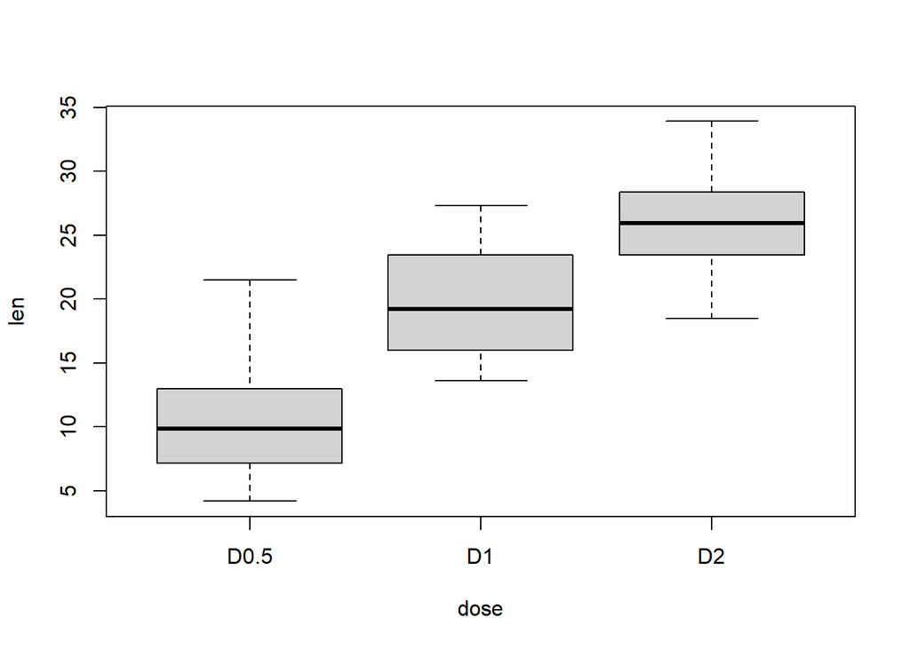

```r
boxplot(len ~ dose, data = my_data)
```

In one-way ANOVA test, a significant p-value indicates that some of the group means are different, but we don’t know which pairs of groups are different.

It’s possible to perform multiple pairwise-comparison, to determine if the mean difference between specific pairs of group are statistically significant using Tukey multiple pairwise-comparisons.

The function TukeyHD() takes the fitted ANOVA as an argument.

```r
# Tukey Significant Differences : why of the average is the different one?
TukeyHSD(res.aov)
```

```
##   Tukey multiple comparisons of means
##     95% family-wise confidence level
##
## Fit: aov(formula = len ~ dose, data = my_data)
##
## $dose
##           diff       lwr       upr    p adj
## D1-D0.5  9.130  5.901805 12.358195 0.00e+00
## D2-D0.5 15.495 12.266805 18.723195 0.00e+00
## D2-D1    6.365  3.136805  9.593195 4.25e-05
```

The output includes the columns diff value (i.e. difference between means of the two groups) and p adj corresponding to the p-value of the test after adjustment for the multiple comparisons.

Considering a significance level alpha = 0.05, all pairwise comparisons are significant.

## Two-way Analysis of Variance (ANOVA)

The standard 2-way ANOVA just adds another Independent Variable to the model. It is used to evaluate simultaneously the effect of two grouping variables.

Null Hypothesis: 1) There is no difference in the means of factor A; 2) There is no difference in means of factor B; 3)There is no interaction between factors A and B

??? We want to know if tooth length depends on supp and dose.

```r
# Analysis of Variance: tooth length depends on supp, dose and their combined effect
res.aov2  = aov(len ~ supp + dose + supp*dose, data= my_data)
# Summary of the analysis
summary(res.aov2)
```

```
##             Df Sum Sq Mean Sq F value   Pr(>F)
## supp         1  205.4   205.4  15.572 0.000231 ***
## dose         2 2426.4  1213.2  92.000  < 2e-16 ***
## supp:dose    2  108.3    54.2   4.107 0.021860 *
## Residuals   54  712.1    13.2
## ---
## Signif. codes:  0 '***' 0.001 '**' 0.01 '*' 0.05 '.' 0.1 ' ' 1
```

```r
print(model.tables(res.aov2,"means"))
```

```
## Tables of means
## Grand mean
##
## 18.81333
##
##  supp
## supp
##     OJ     VC
## 20.663 16.963
##
##  dose
## dose
##   D0.5     D1     D2
## 10.605 19.735 26.100
##
##  supp:dose
##     dose
## supp D0.5  D1    D2
##   OJ 13.23 22.70 26.06
##   VC  7.98 16.77 26.14
```

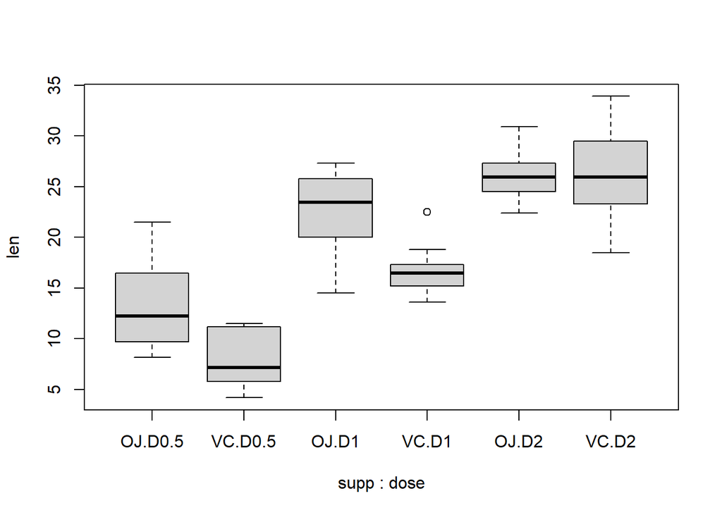

```r
boxplot(len ~ supp + dose + supp*dose, data=my_data)
```

In ANOVA test, a significant p-value indicates that some of the group means are different, but we don’t know which pairs of groups are different…

```r
TukeyHSD(res.aov2)
```

```
##   Tukey multiple comparisons of means
##     95% family-wise confidence level
##
## Fit: aov(formula = len ~ supp + dose + supp * dose, data = my_data)
##
## $supp
##       diff       lwr       upr     p adj
## VC-OJ -3.7 -5.579828 -1.820172 0.0002312
##
## $dose
##           diff       lwr       upr   p adj
## D1-D0.5  9.130  6.362488 11.897512 0.0e+00
## D2-D0.5 15.495 12.727488 18.262512 0.0e+00
## D2-D1    6.365  3.597488  9.132512 2.7e-06
##
## $`supp:dose`
##                  diff        lwr        upr     p adj
## VC:D0.5-OJ:D0.5 -5.25 -10.048124 -0.4518762 0.0242521
## OJ:D1-OJ:D0.5    9.47   4.671876 14.2681238 0.0000046
## VC:D1-OJ:D0.5    3.54  -1.258124  8.3381238 0.2640208
## OJ:D2-OJ:D0.5   12.83   8.031876 17.6281238 0.0000000
## VC:D2-OJ:D0.5   12.91   8.111876 17.7081238 0.0000000
## OJ:D1-VC:D0.5   14.72   9.921876 19.5181238 0.0000000
## VC:D1-VC:D0.5    8.79   3.991876 13.5881238 0.0000210
## OJ:D2-VC:D0.5   18.08  13.281876 22.8781238 0.0000000
## VC:D2-VC:D0.5   18.16  13.361876 22.9581238 0.0000000
## VC:D1-OJ:D1     -5.93 -10.728124 -1.1318762 0.0073930
## OJ:D2-OJ:D1      3.36  -1.438124  8.1581238 0.3187361
## VC:D2-OJ:D1      3.44  -1.358124  8.2381238 0.2936430
## OJ:D2-VC:D1      9.29   4.491876 14.0881238 0.0000069
## VC:D2-VC:D1      9.37   4.571876 14.1681238 0.0000058
## VC:D2-OJ:D2      0.08  -4.718124  4.8781238 1.0000000
```